# TKU STAT × Python Basic

## 資料分析入門

## Kristen Chan

# Agenda

- Numpy
  - Introduction
  - N-dimensional ndarray
  - Create ndarray
  - Inspect
  - Reshaping
  - Mathematics
- Pandas
  - Introduction
  - Structure
  - Reading Files
  - Inspect
  - Descriptive Statistics
- Matplotlib
  - Introduction
  - Basic
  - Plots

# Numpy

# Numpy

### Introduction

- 數值、科學計算
  - 向量、矩陣運算  
    e.g. 加法、減法、乘法
- 主要的物件是 Numpy 陣列 (`ndarray`)
  - 是一個數學物件  
    e.g. 一個向量、一個矩陣
- 使用 Numpy 向量化操作比使用 Python `list` 更快

# Numpy

### Introduction

- 引入 numpy 套件
  - `import numpy`
  - `import numpy as np`  
    以 np 來代表 numpy

```python
import numpy as np
```

# Numpy

### N-dimensional `ndarray`

[figure not shown]

# Numpy

### N-dimensional `ndarray`

- 1d-ndarray

```python
array_1d = np.array( [1,2,3] )
print('array_1d 的資料型態',type(array_1d))
print(array_1d)
```

```
array_1d 的資料型態 <class 'numpy.ndarray'>
[1 2 3]
```

# Numpy

### N-dimensional `ndarray`

- 2d-ndarray

```python
array_2d = np.array( [ [1,2,3],
                       [4,5,6],
                       [7,8,9] ])
print('array_2d 的資料型態',type(array_2d))
print(array_2d)
```

```
array_2d 的資料型態 <class 'numpy.ndarray'>
[[1 2 3]
 [4 5 6]
 [7 8 9]]
```

# Numpy

### Create ndarray

- np.array(x) : 基本建立
- np.zeros(x) : x 是維度 ( 建立一個由 0 組成的 ndarray )
- np.ones(x) : x 是維度 ( 建立一個由 1 組成的 ndarray )
- np.empty(x) : x 是維度 ( 建立一個空的 ndarray )
- np.arange(start, stop, step) : 似 range()
- np.random.random(x) : x 是維度 (隨機產生0~1的值並組成ndarray)
- np.random.uniform(low, high, n) : 隨機產生 n 個介在 low~high 的值並服從 unifom
- np.random.normal(mu, sigma, n) : 隨機產生 n 個服從 normal( $\mu$ , $\sigma$ ) )

# Numpy

### Create ndarray

### Review

Exercise 希望將 Temperature_Taipei 中的所有溫度都轉成華氏

```
Temperature_Taipei = [22, 24, 19, 19, 30, 21, 25]
```

> *公式：* $Fahrenheit = Celsius × (9/5) + 32$

# Numpy

### Create ndarray

### Review

Answer

- 使用 [Loop](https://kristenchan.github.io/Python_DataBasic/py_databasic_ch2.slides.html#/2/26) 幫忙
- 使用 map + lamda ([Review](https://kristenchan.github.io/Python_DataBasic/py_databasic_ch3.slides.html#/3/6))

```python
Temperature_Taipei = [22, 24, 19, 19, 30, 21, 25]
```

```python
print( list( map( lambda i : i * (9/5)+32, Temperature_Taipei ) ) )
```

```
[71.6, 75.2, 66.2, 66.2, 86.0, 69.80000000000001, 77.0]
```

# Numpy

### Create ndarray

- np.array(x) : 基本建立

```python
Temperature_array = np.array( [22, 24, 19, 19, 30, 21, 25] )
```

Note 將 list 轉為 ndarray

```python
Temperature_array = np.array( Temperature_Taipei )
```

# Numpy

### Create ndarray

### Note : 利用 ndarray 將 Temperature_Taipei 中的所有溫度都轉成華氏

```python
Temperature_array_Fahrenheit = (Temperature_array)*(9/5)+32
print(Temperature_array_Fahrenheit)
```

```
[71.6 75.2 66.2 66.2 86.  69.8 77. ]
```

# Numpy

### Create ndarray

- np.zeros(x) : x 是維度 ( 建立一個由 0 組成的 ndarray )

```python
print( np.zeros( (2,3) ) )
```

```
[[0. 0. 0.]
 [0. 0. 0.]]
```

Note ( 2 ,3 ) ：表示一個 `2` 列 `3` 行二維的陣列

# Numpy

### Create ndarray

- np.ones(x) : x 是維度 ( 建立一個由 1 組成的 ndarray )

```python
print( np.ones( (2,3,4) ) )
```

```
[[[1. 1. 1. 1.]
  [1. 1. 1. 1.]
  [1. 1. 1. 1.]]

 [[1. 1. 1. 1.]
  [1. 1. 1. 1.]
  [1. 1. 1. 1.]]]
```

Note ( 2 ,3 ,4 ) ：表示一個 `2` 頁 `3` 列 `4` 行的三維陣列

# Numpy

### Create ndarray

- np.empty(x) : x 是維度 ( 建立一個空的 ndarray )

```python
print( np.empty( (2,2) ) )
```

```
[[-1.72723371e-077  3.11109624e+231]
 [ 2.00390337e+000  2.82476877e-309]]
```

Note 陣列中的元素為一個初始化值

# Numpy

### Create ndarray

- np.empty(x) : x 是維度 ( 建立一個空的 ndarray )

### Note : 將九九乘法表存入一個 2d-ndarray 中

```python
multiplication = np.empty( (9 , 9) )
for i in range(1,10):
    for j in range(1,10):
        multiplication[(i-1),(j-1)]= i*j
```

```python
print(multiplication)
```

```
[[ 1.  2.  3.  4.  5.  6.  7.  8.  9.]
 [ 2.  4.  6.  8. 10. 12. 14. 16. 18.]
 [ 3.  6.  9. 12. 15. 18. 21. 24. 27.]
 [ 4.  8. 12. 16. 20. 24. 28. 32. 36.]
 [ 5. 10. 15. 20. 25. 30. 35. 40. 45.]
 [ 6. 12. 18. 24. 30. 36. 42. 48. 54.]
 [ 7. 14. 21. 28. 35. 42. 49. 56. 63.]
 [ 8. 16. 24. 32. 40. 48. 56. 64. 72.]
 [ 9. 18. 27. 36. 45. 54. 63. 72. 81.]]
```

# Numpy

### Create ndarray

- np.arange(start, stop, step) : 似 range()

```python
print( np.arange(0,10,2) )
```

```
[0 2 4 6 8]
```

Review

```python
print( list(range(0,10,2)) )
```

```
[0, 2, 4, 6, 8]
```

# Numpy

### Create ndarray

- np.random.random(x) : x 是維度 (隨機產生0~1的值並組成ndarray)

隨機產生 0~1 的數值

```python
print( np.random.random( (2,3) ) )
```

```
[[0.10322868 0.00594036 0.71135141]
 [0.76162664 0.5414609  0.14193007]]
```

隨機產生 0~10 的數值

```python
print( np.random.random( (2,3) ) *10 )
```

```
[[3.57881303 2.03389965 5.91201318]
 [5.67424712 2.89686344 7.88636533]]
```

# Numpy

### Create ndarray

- np.random.uniform(low, high, n) : 隨機產生 n 個介在 low~high 的值並服從 unifom

### Note : Uniform Probability Density Function

$$ f(x)=\begin{cases} \frac{1}{b-a} &\text{，for } a \leq x \leq b \\ 0 & \text{，otherwise} \end{cases} $$

[figure not shown]

# Numpy

### Create ndarray

- np.random.uniform(low, high, n) : 隨機產生 n 個介在 low~high 的值並服從 unifom

```python
unifom_distrbution = np.random.uniform(-1,1,25)
print(unifom_distrbution)
```

```
[ 0.71026914 -0.61457316  0.18452574 -0.31136488  0.99949133 -0.30695047
  0.5594765   0.04748817 -0.3808115  -0.27115919 -0.49922516 -0.53045431
 -0.87853298  0.43181305 -0.31889286  0.03479911  0.36622747  0.32436697
  0.12805869 -0.91375168  0.60443956  0.91088484  0.62479195  0.06079643
 -0.60145948]
```

Note 設定 seed 可以固定每次 random 產生的結果

```python
np.random.seed(100)
unifom_distrbution = np.random.uniform(-1,1,25)
print(unifom_distrbution)
```

```
[ 0.08680988 -0.44326123 -0.15096482  0.68955226 -0.99056229 -0.75686176
  0.34149817  0.65170551 -0.72658682  0.15018666  0.78264391 -0.58159576
 -0.62934356 -0.78324622 -0.56060501  0.95724757  0.6233663  -0.65611797
  0.6324495  -0.45185251 -0.13659163  0.88005964  0.63529876 -0.3277761
 -0.64917909]
```

# Numpy

### Create ndarray

- np.random.normal(mu, sigma, n) : 隨機產生 n 個服從 normal( $\mu$ , $\sigma$ ) )

### Note : Normal Density Function

$$ f(x)= \frac{1}{\sqrt{2 \sigma^2 \pi}}e^{-\frac{(x-\mu)^2}{2\sigma^2}} \text{ for } \mu \in R\text{，}\sigma^2 > 0 $$

[figure not shown]

# Numpy

### Create ndarray

- np.random.normal(mu, sigma, n) : 隨機產生 n 個服從 normal( $\mu$ , $\sigma$ ) )

```python
normal_distrbution = np.random.normal( 0 , 1 , 20 )
print(normal_distrbution)
```

```
[ 0.78148842 -0.65438103  0.04117247 -0.20191691 -0.87081315  0.22893207
 -0.40803994 -0.10392514  1.56717879  0.49702472  1.15587233  1.83861168
  1.53572662  0.25499773 -0.84415725 -0.98294346 -0.30609783  0.83850061
 -1.69084816  1.15117366]
```

Note 設定 seed 可以固定每次 random 產生的結果

```python
np.random.seed(100)
normal_distrbution = np.random.normal( 0 , 1 , 20 )
print(normal_distrbution)
```

```
[-1.74976547  0.3426804   1.1530358  -0.25243604  0.98132079  0.51421884
  0.22117967 -1.07004333 -0.18949583  0.25500144 -0.45802699  0.43516349
 -0.58359505  0.81684707  0.67272081 -0.10441114 -0.53128038  1.02973269
 -0.43813562 -1.11831825]
```

# Numpy

### Inspect

- **`.size`** : 這個 `ndarray` 中總共有幾個元素
- **`.shape`** : 這個 `ndarray` 的外觀；e.g. 若 2d-`ndarray` shape : (m × n)
- **`.ndim`** : 這個 `ndarray` 的維度
- **`.dtype`** : 定義或檢查 `ndarray` 的資料型態

# Numpy

### Inspect

- **`.size`** : 這個 `ndarray` 中總共有幾個元素

**Example**

```
print(array_2d)
```

```
[[1 2 3]
 [4 5 6]
 [7 8 9]]
```

Exercise 確認 array_2d 中元素個數

```python
print( array_2d.size )
```

```
9
```

# Numpy

### Inspect

- **`.size`** : 這個 `ndarray` 中總共有幾個元素

Review `len`

```python
my_list = [0, 2, 4, 6, 8]
print( len(my_list) )
```

```
5
```

# Numpy

### Inspect

- **`.shape`** : 這個 `ndarray` 的外觀；e.g. 若 2d-`ndarray` shape : (m × n)

**Example**

```
print(array_2d)
```

```
[[1 2 3]
 [4 5 6]
 [7 8 9]]
```

Exercise 確認 array_2d 中矩陣的外觀

```python
print( array_2d.shape )
```

```
(3, 3)
```

# Numpy

### Inspect

- **`.ndim`** : 這個 `ndarray` 的維度

**Example**

```
print(array_2d)
```

```
[[1 2 3]
 [4 5 6]
 [7 8 9]]
```

Exercise 確認 array_2d 的維度

```python
print( array_2d.ndim )
```

```
2
```

# Numpy

### Inspect

- **`.dtype`** : 定義或檢查 `ndarray` 的資料型態

**Example**

```
print(array_2d)
```

```
[[1 2 3]
 [4 5 6]
 [7 8 9]]
```

Exercise 檢查 array_2d 中元素的型態

```python
print( array_2d.dtype )
```

```
int64
```

# Numpy

### Inspect

- **`.dtype`** : 定義或檢查 `ndarray` 的資料型態

```python
x_int = np.array([1 ,2 ,3] ,dtype=np.int)  #利用 dtype 定義一個 int 的 ndarray
print(x_int)
```

```
[1 2 3]
```

```python
print( "x_int 的資料型態", type(x_int) )
print( "---------------------------------" )
print( "x_int 元素的資料型態", x_int.dtype )
```

```
x_int 的資料型態 <class 'numpy.ndarray'>
---------------------------------
x_int 元素的資料型態 int64
```

Note

- 默認是 64 位元的 int，也有 16, 32 位元
- 位元越小佔用的空間越小，若想要精確就必須用大一點。

# Numpy

### Inspect

- **`.dtype`** : 定義或檢查 `ndarray` 的資料型態

```python
x_float= np.array([1 ,2 ,3] ,dtype=np.float) #利用 dtype 定義一個 float 的 ndarray
print(x_float)
```

```
[1. 2. 3.]
```

```python
print( "x_float 的資料型態", type(x_float) )
print( "---------------------------------" )
print( "x_float 元素的資料型態", x_float.dtype )
```

```
x_float 的資料型態 <class 'numpy.ndarray'>
---------------------------------
x_float 元素的資料型態 float64
```

# Numpy

### Inspect

- **`.dtype`** : 定義或檢查 `ndarray` 的資料型態

```python
x_str = np.array([1 ,2 ,3] ,dtype=np.str) #利用 dtype 定義一個 str 的 ndarray
print(x_str)
```

```
['1' '2' '3']
```

```python
print( "x_str 的資料型態", type(x_str) )
print( "---------------------------------" )
print( "x_str 元素的資料型態", x_str.dtype )
```

```
x_str 的資料型態 <class 'numpy.ndarray'>
---------------------------------
x_str 元素的資料型態 <U1
```

# Numpy

### Inspect

- **`.dtype`** : 定義或檢查 `ndarray` 的資料型態

### Note : ndarray 只接受同一種資料型態

```python
weather_array = np.array([ 'Taipei' , 18.5 , 'rainy' ])
print(weather_array)
print( "---------------------------------" )
print( "weather_array 元素的資料型態", weather_array.dtype )
```

```
['Taipei' '18.5' 'rainy']
---------------------------------
weather_array 元素的資料型態 <U6
```

# Numpy

### Reshaping

- **`.reshape(m,n)`** : 更改 `ndarray` 的外觀
- **`.T`** : 將 `ndarray` 轉置

# Numpy

### Reshaping

- **`.reshape(m,n)`** : 更改 `ndarray` 的外觀

Exercise 隨機生成 一個名為 normal_random (20×1) 的ndarray，服從 normal(0,1)

```python
normal_random = np.random.normal(0,1,20)
print(normal_random)
print( "---------------------------------" )
print( "normal_random 的維度", normal_random.ndim )
print( "---------------------------------" )
print( "normal_random 的外觀", normal_random.shape )
```

```
[ 1.61898166  1.54160517 -0.25187914 -0.84243574  0.18451869  0.9370822
  0.73100034  1.36155613 -0.32623806  0.05567601  0.22239961 -1.443217
 -0.75635231  0.81645401  0.75044476 -0.45594693  1.18962227 -1.69061683
 -1.35639905 -1.23243451]
---------------------------------
normal_random 的維度 1
---------------------------------
normal_random 的外觀 (20,)
```

# Numpy

### Reshaping

- **`.reshape(m,n)`** : 更改 `ndarray` 的外觀

Exercise 利用 .reshape 將 normal_random 資料轉成 2d-ndarray(4X5)

```python
normal_random_new = normal_random.reshape(4,5)
print(normal_random_new)
print( "---------------------------------" )
print( "normal_random_new 的外觀", normal_random_new.shape )
```

```
[[ 1.61898166  1.54160517 -0.25187914 -0.84243574  0.18451869]
 [ 0.9370822   0.73100034  1.36155613 -0.32623806  0.05567601]
 [ 0.22239961 -1.443217   -0.75635231  0.81645401  0.75044476]
 [-0.45594693  1.18962227 -1.69061683 -1.35639905 -1.23243451]]
---------------------------------
normal_random_new 的外觀 (4, 5)
```

# Numpy

### Reshaping

- **`.T`** : 將 `ndarray` 轉置

**Example**

```
print(array_2d)
```

```
[[1 2 3]
 [4 5 6]
 [7 8 9]]
```

Exercise 將 array_2d 轉置

```python
array_2d.T
```

```
array([[1, 4, 7],
       [2, 5, 8],
       [3, 6, 9]])
```

# Numpy

### Mathematics

- **`A * B`** : 兩 `ndarray` 元素相乘 (兩矩陣元素相乘)
- **`np.dot(A , B )`** : 兩 `ndarray` 相乘 (兩矩陣相乘)
- **`np.min(` x `)`** : 找出 `ndarray` 中最小值
- **`np.max(` x `)`** : 找出 `ndarray` 中最大值
- **`np.sum(` x `)`** : 計算這個 `ndarray` 的加總
- **`np.mean(` x `)`** : 平均數
- **`np.std(` x `)`** : 標準差
- **`np.median( )`** : 計算這個 `ndarray` 的中位數

# Numpy

### Mathematics

**Example**

```python
A = np.array([[1,2,3],[4,5,6],[7,8,9]])
print(A)
```

```
[[1 2 3]
 [4 5 6]
 [7 8 9]]
```

```python
B = np.array([[1,1,1],[2,2,2],[3,3,3]])
print(B)
```

```
[[1 1 1]
 [2 2 2]
 [3 3 3]]
```

# Numpy

### Mathematics

**Example**

```
print(A)          print(B)
```

```
[[1 2 3]          [[1 1 1]
 [4 5 6]           [2 2 2]
 [7 8 9]]          [3 3 3]]
```

Exercise 將 A 乘上一個常數

```python
A * 2
```

```
array([[ 2,  4,  6],
       [ 8, 10, 12],
       [14, 16, 18]])
```

# Numpy

### Mathematics

- **`A * B`** : 兩 `ndarray` 元素相乘 (兩矩陣元素相乘)

**Example**

```
print(A)          print(B)
```

```
[[1 2 3]          [[1 1 1]
 [4 5 6]           [2 2 2]
 [7 8 9]]          [3 3 3]]
```

Exercise 將 A , B 兩矩陣元素相乘

```python
A * B
```

```
array([[ 1,  2,  3],
       [ 8, 10, 12],
       [21, 24, 27]])
```

# Numpy

### Mathematics

- **`A * B`** : 兩 `ndarray` 元素相乘 (兩矩陣元素相乘)

### Note : 兩矩陣元素相乘

[figure not shown]

# Numpy

### Mathematics

- **`np.dot(A , B )`** : 兩 `ndarray` 相乘 (兩矩陣相乘)

[figure not shown]

*source:http://www.stoimen.com/blog/wp-content/uploads/2012/11/4.-Rect-Matrix-Multiplication.png*

# Numpy

### Mathematics

- **`np.dot(A , B )`** : 兩 `ndarray` 相乘 (兩矩陣相乘)

**Example**

```
print(A)          print(B)
```

```
[[1 2 3]          [[1 1 1]
 [4 5 6]           [2 2 2]
 [7 8 9]]          [3 3 3]]
```

Exercise 將 A , B 兩矩陣相乘

```python
np.dot(A , B )
```

```
array([[14, 14, 14],
       [32, 32, 32],
       [50, 50, 50]])
```

# Numpy

### Mathematics

- **`np.dot(A , B )`** : 兩 `ndarray` 相乘 (兩矩陣相乘)

### Note : 兩矩陣相乘

[figure not shown]

# Numpy

### Mathematics

- **`np.min(` x `)`** : 找出 `ndarray` 中最小值
- **`np.max(` x `)`** : 找出 `ndarray` 中最大值

**Example**

```
print(normal_distrbution)
```

```
[-1.74976547  0.3426804   1.1530358  -0.25243604  0.98132079
  0.51421884  0.22117967 -1.07004333 -0.18949583  0.25500144
 -0.45802699  0.43516349 -0.58359505  0.81684707  0.67272081
 -0.10441114 -0.53128038  1.02973269 -0.43813562 -1.11831825]
```

Exercise 分別找出 normal_distrbution 中最大、最小值

```python
print("normal_distrbution 的最小值：", np.min(normal_distrbution))
print("normal_distrbution 的最大值：", np.max(normal_distrbution))
```

```
normal_distrbution 的最小值： -1.7497654730546974
normal_distrbution 的最大值： 1.153035802563644
```

# Numpy

### Mathematics

- **`np.sum(` x `)`** : 計算這個 `ndarray` 的加總
- **`np.mean(` x `)`** : 平均數
- **`np.std(` x `)`** : 標準差
- **`np.median( )`** : 計算這個 `ndarray` 的中位數

Exercise 分別找出 normal_distrbution 的總和、平均數、標準差、中位數

```python
print("normal_distrbution 的總和：", np.sum(normal_distrbution))
print("normal_distrbution 的平均數：", np.mean(normal_distrbution))
print("normal_distrbution 的標準差：", np.std(normal_distrbution))
print("normal_distrbution 的中位數：", np.median(normal_distrbution))
```

```
normal_distrbution 的總和： -0.07360709761201556
normal_distrbution 的平均數： -0.003680354880600778
normal_distrbution 的標準差： 0.7664839465468608
normal_distrbution 的中位數： 0.05838426291538637
```

# Pandas

# Pandas

### Introduction

- 基於 Numpy
- 用於數據分析，提供容易操作的資料結構及分析工具
- 引入 Pandas
  - `import pandas`
  - `import pandas as pd`  
    以 pd 來代表 pandas

```python
import pandas as pd
```

# Pandas

### Structure

[figure not shown]

*source:https://github.com/pandas-dev/pandas*

# Pandas

### Structure

- **`Series`**
  - 類似 `numpy` 中的 1d-`ndarray`
  - 每個元素都有各自的索引值(標籤)
  - 底層是 `ndarray`
- **`DataFrame`**
  - 類似 `numpy` 中的 2d-`ndarray`
  - 由 `pd.Series` 組成
  - 可儲存不同類型的資料
  - 有欄、列索引值(標籤)

# Pandas

### Structure

- **`Series`**
  - Create a Series ( 1D-Ndarray to pd.Series )

```python
Taipei_array = np.array([17.0,8.3,20.1,22.6,27.0,27.8,30.1,30.3,29.4,27.1,24.0,17.5,])
print("Taipei_array 的資料型態", type(Taipei_array))
print( "---------------------------------" )
print(Taipei_array)
```

```
Taipei_array 的資料型態 <class 'numpy.ndarray'>
---------------------------------
[17.   8.3 20.1 22.6 27.  27.8 30.1 30.3 29.4 27.1 24.  17.5]
```

# Pandas

### Structure

- **`Series`**
  - Create a Series ( 1D-Ndarray to pd.Series )

```python
Taipei_series = pd.Series(Taipei_array)
print("Taipei_series 的資料型態", type(Taipei_series))
print( "---------------------------------" )
print(Taipei_series)
```

```
Taipei_series 的資料型態 <class 'pandas.core.series.Series'>
---------------------------------
0     17.0
1      8.3
2     20.1
3     22.6
4     27.0
5     27.8
6     30.1
7     30.3
8     29.4
9     27.1
10    24.0
11    17.5
dtype: float64
```

# Pandas

### Structure

- **`Series`**
  - Create a Series ( 1D-Ndarray to pd.Series )，加入 index

```python
month = [ 'FEB', 'JAN', 'MAR', 'APR', 'MAY', 'JUN', 'JUL', 'AUG', 'SEP', 'OCT', 'NOV', 'DEC']
```

```python
Taipei_series = pd.Series( Taipei_array ,
                           index = month )
```

```python
print(Taipei_series)
```

```
FEB    17.0
JAN     8.3
MAR    20.1
APR    22.6
MAY    27.0
JUN    27.8
JUL    30.1
AUG    30.3
SEP    29.4
OCT    27.1
NOV    24.0
DEC    17.5
dtype: float64
```

# Pandas

### Structure

- **`Series`**
  - Create a Series ( 1D-Ndarray to pd.Series )

### Note : index 有什麼好處 ?

```python
print(Taipei_series['FEB'])
```

```
17.0
```

# Pandas

### Structure

- **`Series`**
  - Dictionary to pd.Series

```python
Taipei_dic = {'FEB': 17.0, 'JAN': 8.3, 'MAR': 20.1, 'APR': 22.6, 'MAY': 27.0, 'JUN': 27.8, 'JUL': 30.1, 'AUG': 30.3, 'SEP': 29.4, 'OCT': 27.1, 'NOV': 24.0, 'DEC': 17.5}
print("Taipei_dic 的資料型態", type(Taipei_dic))
print( "---------------------------------" )
print(Taipei_dic)
```

```
Taipei_dic 的資料型態 <class 'dict'>
---------------------------------
{'FEB': 17.0, 'JAN': 8.3, 'MAR': 20.1, 'APR': 22.6, 'MAY': 27.0, 'JUN': 27.8, 'JUL': 30.1, 'AUG': 30.3, 'SEP': 29.4, 'OCT': 27.1, 'NOV': 24.0, 'DEC': 17.5}
```

# Pandas

### Structure

- **`Series`**
  - Dictionary to pd.Series

Note Dictionary 的 Key 會變成 index

```python
Taipei_series = pd.Series(Taipei_dic)
print("Taipei_series 的資料型態", type(Taipei_series))
print( "---------------------------------" )
print(Taipei_series)
```

```
Taipei_series 的資料型態 <class 'pandas.core.series.Series'>
---------------------------------
APR    22.6
AUG    30.3
DEC    17.5
FEB    17.0
JAN     8.3
JUL    30.1
JUN    27.8
MAR    20.1
MAY    27.0
NOV    24.0
OCT    27.1
SEP    29.4
dtype: float64
```

# Pandas

### Structure

- **`DataFrame`**
  - Create a DataFrame ( 2D-Ndarray to pd.DataFrame )

```python
Temperature = np.array([[17.0,8.3,20.1,22.6,27.0,27.8,30.1,30.3,29.4,27.1,24.0,17.5],
                        [21.1,21.7,22.9,25.7,28.4,28.4,29.4,30.2,29.7,28.9,26.9,21.6]])
print("Temperature 的資料型態", type(Temperature))
print( "---------------------------------" )
print("Temperature 的外觀", np.shape(Temperature))
print( "---------------------------------" )
print(Temperature)
```

```
Temperature 的資料型態 <class 'numpy.ndarray'>
---------------------------------
Temperature 的外觀 (2, 12)
---------------------------------
[[17.   8.3 20.1 22.6 27.  27.8 30.1 30.3 29.4 27.1 24.  17.5]
 [21.1 21.7 22.9 25.7 28.4 28.4 29.4 30.2 29.7 28.9 26.9 21.6]]
```

# Pandas

### Structure

- **`DataFrame`**
  - Create a DataFrame ( 2D-Ndarray to pd.DataFrame )

```python
Temperature_dataframe = pd.DataFrame(Temperature)
print("Temperature_dataframe 的資料型態", type(Temperature_dataframe))
print( "---------------------------------" )
print(Temperature_dataframe)
```

```
Temperature_dataframe 的資料型態 <class 'pandas.core.frame.DataFrame'>
---------------------------------
     0     1     2     3     4     5     6     7     8     9     10    11
0  17.0   8.3  20.1  22.6  27.0  27.8  30.1  30.3  29.4  27.1  24.0  17.5
1  21.1  21.7  22.9  25.7  28.4  28.4  29.4  30.2  29.7  28.9  26.9  21.6
```

# Pandas

### Structure

- **`DataFrame`**
  - Create a DataFrame ( 2D-Ndarray to pd.DataFrame )，加入 index 及 column name

```python
Temperature_dataframe = pd.DataFrame(Temperature,
                                     index=['Taipei','Kaohsiung'],
                                     columns = month)
```

```python
print(Temperature_dataframe)
```

```
            FEB   JAN   MAR   APR   MAY   JUN   JUL   AUG   SEP   OCT   NOV  \
Taipei     17.0   8.3  20.1  22.6  27.0  27.8  30.1  30.3  29.4  27.1  24.0
Kaohsiung  21.1  21.7  22.9  25.7  28.4  28.4  29.4  30.2  29.7  28.9  26.9

            DEC
Taipei     17.5
Kaohsiung  21.6
```

# Pandas

### Structure

- **`DataFrame`**
  - Dictionary to pd.DataFrame

```python
Temperature_dic = {'FEB': [17.0,21.1], 'JAN': [8.3,21.7], 'MAR': [20.1,22.9], 'APR': [22.6,25.7], 'MAY': [27.0,28.4], 'JUN': [27.8,28.4],'JUL': [30.1,29.4], 'AUG': [30.3,30.2], 'SEP': [29.4,29.7], 'OCT': [27.1,28.9], 'NOV':[24.0,26.9], 'DEC': [17.5,21.6]}
print("Temperature_dic 的資料型態", type(Temperature_dic))
print( "---------------------------------" )
print(Temperature_dic)
```

```
Temperature_dic 的資料型態 <class 'dict'>
---------------------------------
{'FEB': [17.0, 21.1], 'JAN': [8.3, 21.7], 'MAR': [20.1, 22.9], 'APR': [22.6, 25.7], 'MAY': [27.0, 28.4], 'JUN': [27.8, 28.4], 'JUL': [30.1, 29.4], 'AUG': [30.3, 30.2], 'SEP': [29.4, 29.7], 'OCT': [27.1, 28.9], 'NOV': [24.0, 26.9], 'DEC': [17.5, 21.6]}
```

# Pandas

### Structure

- **`DataFrame`**
  - Dictionary to pd.DataFrame

Note Dictionary 的 Key 會變成 column name

```python
Temperature_dataframe = pd.DataFrame(Temperature_dic)
print("Temperature_dataframe 的資料型態", type(Temperature_dataframe))
print( "---------------------------------" )
print(Temperature_dataframe)
```

```
Temperature_dataframe 的資料型態 <class 'pandas.core.frame.DataFrame'>
---------------------------------
    APR   AUG   DEC   FEB   JAN   JUL   JUN   MAR   MAY   NOV   OCT   SEP
0  22.6  30.3  17.5  17.0   8.3  30.1  27.8  20.1  27.0  24.0  27.1  29.4
1  25.7  30.2  21.6  21.1  21.7  29.4  28.4  22.9  28.4  26.9  28.9  29.7
```

# Pandas

### Structure

```python
Temperature_dataframe = pd.DataFrame(Temperature,
                                     columns = month)
```

```python
print(Temperature_dataframe)
```

```
    FEB   JAN   MAR   APR   MAY   JUN   JUL   AUG   SEP   OCT   NOV   DEC
0  17.0   8.3  20.1  22.6  27.0  27.8  30.1  30.3  29.4  27.1  24.0  17.5
1  21.1  21.7  22.9  25.7  28.4  28.4  29.4  30.2  29.7  28.9  26.9  21.6
```

# Pandas

### Structure

```python
Temperature_dataframe = pd.DataFrame(Temperature,
                                     columns = month,
                                     index=['Taipei','Kaohsiung'])
```

```python
print(Temperature_dataframe)
```

```
            FEB   JAN   MAR   APR   MAY   JUN   JUL   AUG   SEP   OCT   NOV  \
Taipei     17.0   8.3  20.1  22.6  27.0  27.8  30.1  30.3  29.4  27.1  24.0
Kaohsiung  21.1  21.7  22.9  25.7  28.4  28.4  29.4  30.2  29.7  28.9  26.9

            DEC
Taipei     17.5
Kaohsiung  21.6
```

# Pandas

### Note : Demo Data (可包含不同類型的資料)

```python
Taipei = [17.0,8.3,20.1,22.6,27.0,27.8,30.1,30.3,29.4,27.1,24.0,17.5]
Kaohsiung = [21.1,21.7,22.9,25.7,28.4,28.4,29.4,30.2,29.7,28.9,26.9,21.6]
Quality = ['Good','Good','Bad','Bad','Bad','Good','Bad','Bad','Good','Bad','Good','Good']

Temperature = { 'Taipei' : Taipei ,
                'Kaohsiung' : Kaohsiung ,
                'Quality' : Quality }

Temperature_dataframe = pd.DataFrame(Temperature, index = month)
print(Temperature_dataframe)
```

```
     Kaohsiung Quality  Taipei
FEB       21.1    Good    17.0
JAN       21.7    Good     8.3
MAR       22.9     Bad    20.1
APR       25.7     Bad    22.6
MAY       28.4     Bad    27.0
JUN       28.4    Good    27.8
JUL       29.4     Bad    30.1
AUG       30.2     Bad    30.3
SEP       29.7    Good    29.4
OCT       28.9     Bad    27.1
NOV       26.9    Good    24.0
DEC       21.6    Good    17.5
```

# Pandas

### Reading Files

- **`.read_csv( )`** : 讀取 csv 格式資料
- **`.read_excel( )`** : 讀取 excel 資料
- **`.read_json( )`** : 讀取 JSON 格式資料

# Pandas

### Reading Files

### Note : 檢查目前所在目錄

```python
import os
os.getcwd()
```

```
'/Users/hsinyuchan/Desktop/TKUXPython'
```

# Pandas

### Reading Files

### Note : 淺談電腦編碼

- UTF-8
- Big5
- ASCII

*source:http://blog.chunnorris.cc/2015/04/unicode.html*

# Pandas

### Reading Files

- **`.read_csv( )`** : 讀取 csv 格式資料

**2002 - 2016 年國民出國目的地人數統計**  
*source:政府開放資料 http://data.gov.tw/node/7325*

```python
Aboard = pd.read_csv('/Users/hsinyuchan/Desktop/TKUXPython/Data/Aboard.csv',encoding='big5')
```

```python
Aboard.head()
```

|  | 首站抵達地 | 細分 | 2002 | 2003 | 2004 | 2005 | 2006 | 2007 | 2008 | 2009 | 2010 | 2011 | 2012 | 2013 | 2014 | 2015 | 2016 |
| --- | --- | --- | --- | --- | --- | --- | --- | --- | --- | --- | --- | --- | --- | --- | --- | --- | --- |
| 0 | 亞洲地區 | 香港 Hong Kong | 2418872 | 1,869,069 | 2,559,705 | 2,807,027 | 2,993,317 | 3,030,971 | 2,851,170 | 2,261,001 | 2,308,633 | 2,156,760 | 2,021,212 | 2,038,732 | 2,018,129 | 2,008,153 | 1,902,647 |
| 1 | 亞洲地區 | 大陸 Mainland China | 1 | 44 | - | - | - | - | 188,744 | 1,516,087 | 2,424,242 | 2,846,572 | 3,139,055 | 3,072,327 | 3,267,238 | 3,403,920 | 3,685,477 |
| 2 | 亞洲地區 | 日本 Japan | 797460 | 731,330 | 1,051,954 | 1,180,406 | 1,214,058 | 1,280,853 | 1,309,847 | 1,113,857 | 1,377,957 | 1,136,394 | 1,560,300 | 2,346,007 | 2,971,846 | 3,797,879 | 4,295,240 |
| 3 | 亞洲地區 | 韓國 Korea,Republic of | 120208 | 179,893 | 298,325 | 368,206 | 396,705 | 457,095 | 363,122 | 388,806 | 406,290 | 423,266 | 532,729 | 518,528 | 626,694 | 500,100 | 808,420 |
| 4 | 亞洲地區 | 新加坡 Singapore | 190455 | 125,491 | 160,088 | 184,926 | 204,834 | 189,835 | 167,479 | 137,348 | 166,126 | 207,808 | 241,893 | 297,588 | 283,925 | 318,516 | 319,915 |

# Pandas

### Reading Files

- **`.read_excel( )`** : 讀取 excel 資料

**100-104 年各縣市消防人力人數統計**  
*source:內政部統計查詢網 http://statis.moi.gov.tw/micst/stmain.jsp?sys=100*

```python
Fire = pd.read_excel('/Users/hsinyuchan/Desktop/TKUXPython/Data/Fire.xlsx')
```

```python
Fire.head()
```

|  | 年度 | 區域 | 男 | 女 | 未滿25歲 | 25-29歲 | 30-34歲 | 35-39歲 | 40-44歲 | 45-49歲 | 50-54歲 | 55-59歲 | 60-64歲 | 65歲以上 |
| --- | --- | --- | --- | --- | --- | --- | --- | --- | --- | --- | --- | --- | --- | --- |
| 0 | 100年 | 新北市 | 1833 | 244 | 263 | 880 | 540 | 163 | 93 | 89 | 29 | 15 | 5 | 0 |
| 1 | 100年 | 臺北市 | 1424 | 220 | 194 | 329 | 435 | 267 | 132 | 166 | 93 | 19 | 8 | 1 |
| 2 | 100年 | 桃園市 | 905 | 110 | 199 | 311 | 211 | 107 | 73 | 80 | 28 | 4 | 2 | 0 |
| 3 | 100年 | 臺中市 | 974 | 117 | 136 | 266 | 220 | 136 | 116 | 145 | 59 | 12 | 1 | 0 |
| 4 | 100年 | 臺南市 | 841 | 78 | 20 | 145 | 230 | 165 | 119 | 156 | 73 | 9 | 2 | 0 |

# Pandas

### Reading Files

- **`.read_json( )`** : 讀取 JSON 格式資料

**臺北市施工資訊**  
*source:台北市政府資料開放平台 http://data.taipei/opendata/datalist/datasetMeta?oid=4d29818c-a3ee-425d-b88a-22ac0c24c712*

```python
construction = pd.read_json('/Users/hsinyuchan/Desktop/TKUXPython/Data/construction.json')
```

```python
construction.head(1)
```

|  | AC_NO | ADDR | APPMODE | APPTIME | APP_NAME | CB_DA | CE_DA | CO_TI | C_NAME | DELAYTIME | ... | ST_NO | TC_MA | TC_MA3 | TC_MA3ID | TC_MAID | TC_NA | TC_TL | TC_TL3 | X | Y |
| --- | --- | --- | --- | --- | --- | --- | --- | --- | --- | --- | --- | --- | --- | --- | --- | --- | --- | --- | --- | --- | --- |
| 0 | 102004900 | 紹興南街17~21-3號與仁愛路1段1~19號 | 0 | 1061121091240 | 台電輸變電 | 1020708 | 1061225 | 依交維計畫訂定時間施工 2月11日-3月2日禁止道路施工 | 中正 | NaN | ... | 1 | 黃少榮 | 連彥宇 | F126173460 | G121445426 | 長聖營造有限公司 | 988038303 | 937141297 | 302673.265 | 2770188.888 |

1 rows × 23 columns

# Pandas

### Reading Files

- **`.read_json( )`** : 讀取 JSON 格式資料

### Note : Encoding Problem

```python
import codecs
```

```python
construction = pd.read_json(codecs.open('/Users/hsinyuchan/Desktop/TKUXPython/Data/construction.json', 'r', 'utf-8'))
```

# Pandas

### Inspect

- **`.head(` n `)`** : 看前 n 筆資料
- **`.tail(` n `)`** : 看後 n 筆資料
- **`.info( )`** : 整體資料狀況

# Pandas

### Inspect

**Use Demo Data**

```python
Temperature_dataframe
```

|  | Kaohsiung | Quality | Taipei |
| --- | --- | --- | --- |
| FEB | 21.1 | Good | 17.0 |
| JAN | 21.7 | Good | 8.3 |
| MAR | 22.9 | Bad | 20.1 |
| APR | 25.7 | Bad | 22.6 |
| MAY | 28.4 | Bad | 27.0 |
| JUN | 28.4 | Good | 27.8 |
| JUL | 29.4 | Bad | 30.1 |
| AUG | 30.2 | Bad | 30.3 |
| SEP | 29.7 | Good | 29.4 |
| OCT | 28.9 | Bad | 27.1 |
| NOV | 26.9 | Good | 24.0 |
| DEC | 21.6 | Good | 17.5 |

# Pandas

### Inspect

- **`.head(` n `)`** : 看前 n 筆資料

Exercise 查看 Temperature_dataframe 的前五筆資料

```python
Temperature_dataframe.head(5)
```

|  | Kaohsiung | Quality | Taipei |
| --- | --- | --- | --- |
| FEB | 21.1 | Good | 17.0 |
| JAN | 21.7 | Good | 8.3 |
| MAR | 22.9 | Bad | 20.1 |
| APR | 25.7 | Bad | 22.6 |
| MAY | 28.4 | Bad | 27.0 |

# Pandas

### Inspect

- **`.tail(` n `)`** : 看後 n 筆資料

Exercise 查看 Temperature_dataframe2 的後三筆資料

```python
Temperature_dataframe.tail(3)
```

|  | Kaohsiung | Quality | Taipei |
| --- | --- | --- | --- |
| OCT | 28.9 | Bad | 27.1 |
| NOV | 26.9 | Good | 24.0 |
| DEC | 21.6 | Good | 17.5 |

# Pandas

### Inspect

- **`.info( )`** : 整體資料狀況

Exercise 確認 Temperature_dataframe 的欄位資料類型

```python
Temperature_dataframe.info()
```

```
<class 'pandas.core.frame.DataFrame'>
Index: 12 entries, FEB to DEC
Data columns (total 3 columns):
Kaohsiung    12 non-null float64
Quality      12 non-null object
Taipei       12 non-null float64
dtypes: float64(2), object(1)
memory usage: 384.0+ bytes
```

# Pandas

### Descriptive Statistics

- **`.describe( )`** : 資料中連續型資料的基本統計敘述
- **`.value_counts( )`** : 資料中類別型資料的次數

# Pandas

### Descriptive Statistics

### Note : Data science process flowchart

[figure not shown]

*source: https://www.wikiwand.com/en/Data_analysis*

# Pandas

### Descriptive Statistics

### Note

| Category | Continuous |  |
| --- | --- | --- |
| 次 數 | Central | Dispersion |
|  | 平均數 | 標準差 |
|  | 中位數 | 全 距 |
|  | 眾 數 | 四分位差 |

# Pandas

### Descriptive Statistics

- **`.describe( )`** : 資料中連續型資料的基本統計敘述

Exercise 查看 Temperature_dataframe 中連續型資料的基本統計敘述

```python
Temperature_dataframe.describe()
```

|  | Kaohsiung | Taipei |
| --- | --- | --- |
| count | 12.000000 | 12.000000 |
| mean | 26.241667 | 23.433333 |
| std | 3.496611 | 6.675373 |
| min | 21.100000 | 8.300000 |
| 25% | 22.600000 | 19.450000 |
| 50% | 27.650000 | 25.500000 |
| 75% | 29.025000 | 28.200000 |
| max | 30.200000 | 30.300000 |

# Pandas

### Descriptive Statistics

- **`.value_counts( )`** : 資料中類別型資料的次數

Exercise 查看 Temperature_dataframe 中類別型資料的次數

```python
Temperature_dataframe['Quality'].value_counts()
```

```
Bad     6
Good    6
Name: Quality, dtype: int64
```

# Matplotlib

# Matplotlib

### Introduction

- 引入 matplotlib 套件
  - import matplotlib.pyplot as plt
- 讓圖畫在 Jupyter Notebook 中
  - %matplotlib inline

```python
import matplotlib.pyplot as plt
```

# Matplotlib

### Note : Data science process flowchart

[figure not shown]

*source: https://www.wikiwand.com/en/Data_analysis*

# Matplotlib

- 探索型視覺化

  > https://www.youtube.com/watch?v=DbJyPELmhJc&feature=youtu.be
- 解釋型視覺化

  > https://www.youtube.com/watch?v=6F29XLEZCXc

# Matplotlib

### Basic

- `plt.xlabel( )` / `plt.ylabel( )`：X 軸標籤 / Y 軸標籤
- `plt.xlim( )` / `plt.ylim( )`：X 軸範圍 / Y 軸範圍
- `plt.title( )`：圖標題
- `plt.grid( )`：格線
- `plt.legend`：圖例
- `plt.subplot`：子圖
- `plt.show`：將畫好的圖顯示出來
- `plt.savefig`：另存圖檔

# Matplotlib

### Note : Demo Data

```python
Year = ['2014','2014','2014','2014','2014','2014','2014','2014','2014','2014','2014','2014',
        '2015','2015','2015','2015','2015','2015','2015','2015','2015','2015','2015','2015',
        '2016','2016','2016','2016','2016','2016','2016','2016','2016','2016','2016','2016']
Month = ['JAN','FEB','MAR','APR','MAY','JUN','JUL','AUG','SEP','OCT','NOV','DEC',
         'JAN','FEB','MAR','APR','MAY','JUN','JUL','AUG','SEP','OCT','NOV','DEC',
         'JAN','FEB','MAR','APR','MAY','JUN','JUL','AUG','SEP','OCT','NOV','DEC']
Season = ['Winter','Winter','Spring','Spring','Spring','Summer','Summer','Summer','Fall','Fall','Fall','Winter',
          'Winter','Winter','Spring','Spring','Spring','Summer','Summer','Summer','Fall','Fall','Fall','Winter',
          'Winter','Winter','Spring','Spring','Spring','Summer','Summer','Summer','Fall','Fall','Fall','Winter']
Taipei = [16.8,16.5,18.9,22.5,25.2,28.0,30.5,30.2,29.7,24.7,22.3,16.5,
          16.7,20.8,18.9,22.7,26.1,30.0,30.0,28.6,27.4,25.2,23.5,18.9,
          16.2,15.5,17.5,24.0,27.1,29.4,30.3,30.1,27.8,27.0,22.6,20.1]
Taichung = [16.4,17.0,19.8,24.1,25.8,28.6,30.1,28.9,29.2,25.6,23.1,17.1,
            17.1,18.1,20.7,24.4,26.9,29.7,29.2,28.0,27.8,26.2,24.3,19.6,
            16.8,16.4,18.3,24.9,27.6,28.8,29.4,28.9,27.9,27.5,23.4,20.4]
Kaohsiung = [19.5,20.3,22.6,25.9,27.8,29.2,30.3,29.1,29.5,27.2,25.2,20.2,
             19.9,17.3,23.6,26.2,28.3,30.6,29.5,28.8,28.8,27.7,26.2,22.4,
             19.3,19.6,21.6,26.9,28.9,29.7,30.2,29.4,28.4,28.4,25.7,22.9]
Temperature_table = { "Year" : Year,
                      "Month" : Month,
                      "Season" : Season,
                      "Taipei" : Taipei,
                      "Taichung" : Taichung,
                      "Kaohsiung" : Kaohsiung }
Temperature = pd.DataFrame(Temperature_table)
print(Temperature.shape)
Temperature.head()
```

```
(36, 6)
```

|  | Kaohsiung | Month | Season | Taichung | Taipei | Year |
| --- | --- | --- | --- | --- | --- | --- |
| 0 | 19.5 | JAN | Winter | 16.4 | 16.8 | 2014 |
| 1 | 20.3 | FEB | Winter | 17.0 | 16.5 | 2014 |
| 2 | 22.6 | MAR | Spring | 19.8 | 18.9 | 2014 |
| 3 | 25.9 | APR | Spring | 24.1 | 22.5 | 2014 |
| 4 | 27.8 | MAY | Spring | 25.8 | 25.2 | 2014 |

# Matplotlib

### Note : Demo Data

```python
Taipei_Season = Temperature['Taipei'].groupby(Temperature['Season']).mean()
Taipei_Season
```

```
Season
Fall      25.577778
Spring    22.544444
Summer    29.677778
Winter    17.555556
Name: Taipei, dtype: float64
```

# Matplotlib

### Plots

- `scatter( )`：Scatter plot 散佈圖
- `plot( )`：Line plot 線圖
- `hist( )`：Histogram 直方圖
- `bar( )` / `barh`：Bar plot 長條圖

# Matplotlib

### Plots

- `scatter( )`：Scatter plot 散佈圖

Exercise 想知道 Temperature 資料中 台北市 及 台中市 溫度的關係

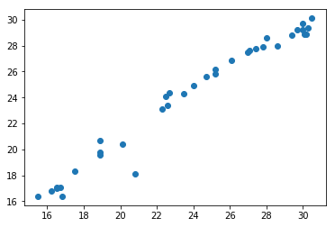

```python
plt.scatter(Temperature['Taipei'], Temperature['Taichung'])
plt.show()
```

# Matplotlib

### Plots

- `scatter( )`：Scatter plot 散佈圖

Exercise 想知道 Temperature 資料中 台北市 及 台中市 溫度的關係，加入標籤及標題

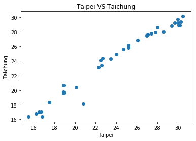

```python
x = Temperature['Taipei']
y = Temperature['Taichung']
plt.scatter(x, y)
plt.xlabel("Taipei")
plt.ylabel("Taichung")
plt.title("Taipei VS Taichung")
plt.show()
```

# Matplotlib

### Plots

- `plot( )`：Line plot 線圖

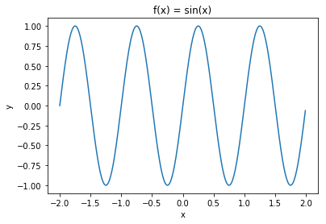

```python
x = np.arange(-2.0, 2.0, 0.01)
y = np.sin(2 * np.pi * x)

plt.plot(x, y)
plt.xlabel("x")
plt.ylabel("y")
plt.title("f(x) = sin(x)")
plt.show()
```

# Exercise

## Q. Line Plot

$$ f(x) = x^2 ; -2 \le x \le 2 $$

# Answers

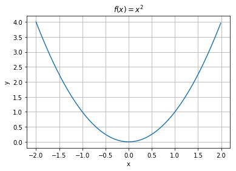

```python
x = np.arange(-2.0, 2.0, 0.01)
y = x**2

plt.plot(x, y)
plt.xlabel("x")
plt.ylabel("y")
plt.title("$f(x) = x^2$")
plt.grid(True)
plt.show()
```

# Matplotlib

### Plots

- `hist( )`：Histogram 直方圖

**Normal distribution ( size = 10000 )**

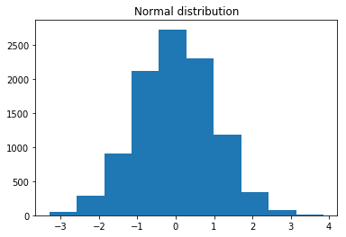

```python
normal_data = np.random.normal(size = 10000)
plt.hist(normal_data)
plt.title("Normal distribution")
plt.show()
```

# Matplotlib

### Plots

- `hist( )`：Histogram 直方圖

**Uniform distribution ( size = 10000 )**

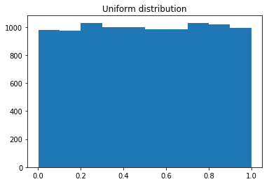

```python
uniform_data = np.random.uniform(size = 10000)
plt.hist(uniform_data)
plt.title("Uniform distribution")
plt.show()
```

# Matplotlib

### Plots

### Note : 左右圖

- Normal distribution ( size = 10000) ← 左
- Uniform distribution ( size = 10000 ) ← 右

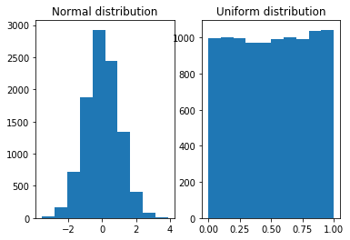

```python
normal_data = np.random.normal(size = 10000)
uniform_data = np.random.uniform(size = 10000)
plt.subplot(1, 2, 1)
plt.hist(normal_data)
plt.title("Normal distribution")
plt.subplot(1, 2, 2)
plt.hist(uniform_data)
plt.title("Uniform distribution")
plt.show()
```

# Matplotlib

### Plots

- `bar( )` / `barh`：Bar plot 長條圖

Exercise 利用 Taipei_Season 畫一個，台北在不同季節下的溫度變化

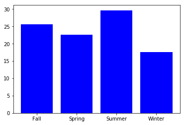

```python
season_cut = range(len(Taipei_Season))
plt.bar(season_cut , Taipei_Season, color="blue", align = "center")
plt.xticks(season_cut , Taipei_Season.index)
plt.show()
```